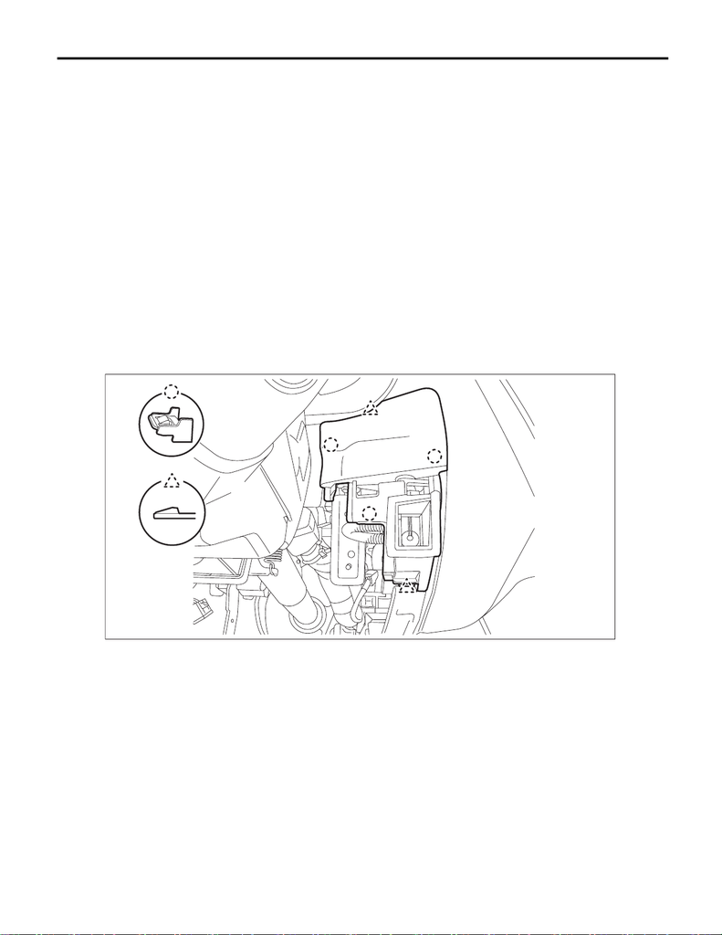

AB-36

Passenger’s Airbag Module

AIRBAG SYSTEM

6. Passenger’s Airbag Module

A: REMOVAL

CAUTION:

Refer to “CAUTION” of “General Description” before handling the airbag module. <Ref. to AB-9,

CAUTION, General Description.>

1) Turn the ignition switch to OFF.

2) Disconnect the ground cable from battery and wait for at least 60 seconds before starting work. <Ref. to

NT-5, BATTERY, NOTE, Note.>

NOTE:

• For models other than STI model, disconnect the ground terminal from battery sensor.

• On CVT models, shift the select lever into “D” before disconnecting the battery ground cable.

• For the power seat, remove the console box before removing the battery ground terminal.

3) Remove the console box assembly, the cover - shift lever and the panel center LWR on the RH and LH

sides. <Ref. to EI-67, REMOVAL, Console Box.>

4) Remove the cover assembly - instrument panel LWR driver. <Ref. to EI-61, REMOVAL, Instrument Panel

Lower Cover.>

5) Remove the cover switch - starter.

(1) Release the claws and remove the cover switch - starter.

(2) Disconnect the connector and aspirator hose.

6) Remove the panel - switch. (Only model with keyless access)

(1) Release the claw of the switch - push button start, and disconnect the connector.

(2) Release the claws, and then remove the panel - switch.

EI-03532

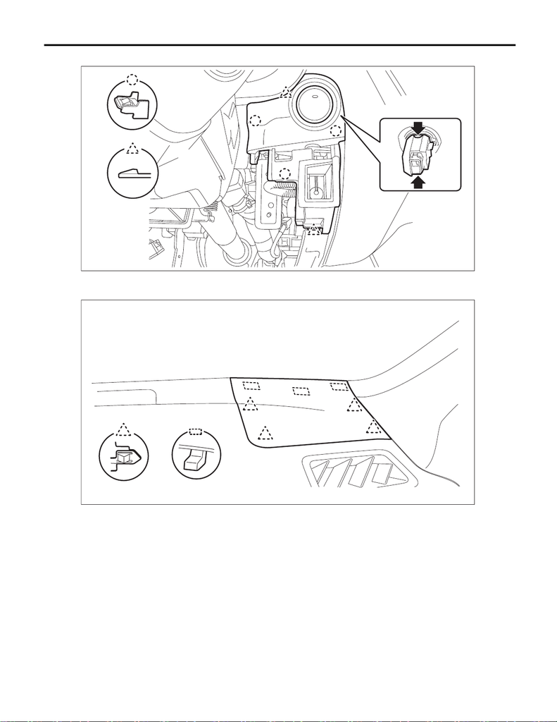

AB-37

Passenger’s Airbag Module

AIRBAG SYSTEM

(3) Disconnect the connector and aspirator hose.

7) Remove the knee airbag module. <Ref. to AB-35, REMOVAL, Knee Airbag Module.>

8) Release the clips and claws, then detach the left and right grille speaker side.

NOTE:

Remove the grille speaker side by using a plastic remover.

9) Remove the trim panel - front pillar UPR on the left and right sides. <Ref. to EI-85, REMOVAL, Upper Inner

Trim.>

10) Remove the glove box assembly. <Ref. to EI-63, REMOVAL, Glove Box.>

11) Remove the panel center assembly. <Ref. to EI-66, REMOVAL, Center Console.>

12) Remove the audio assembly or navigation assembly. <Ref. to ET-8, REMOVAL, Audio.>

13) Remove the multi-function display assembly. <Ref. to IDI-20, REMOVAL, Multi-function Display (MFD).>

14) Remove the combination meter assembly. <Ref. to IDI-13, REMOVAL, Combination Meter.>

SL-01599

EI-03437

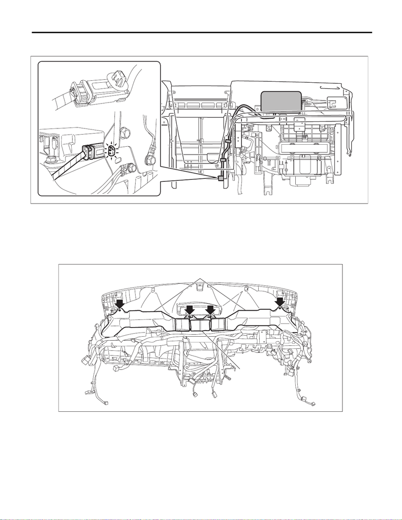

AB-38

Passenger’s Airbag Module

AIRBAG SYSTEM

15) Disconnect the passenger’s airbag module connector. <Ref. to AB-19, PASSENGER’S AIRBAG MOD-

ULE, PROCEDURE, Airbag Connector.>

16) Remove the column assembly - steering. <Ref. to PS-25, REMOVAL, Steering Column.>

17) Remove the cover side sill - front INN and cover side sill - front on the RH and LH side. <Ref. to EI-81,

REMOVAL, Lower Inner Trim.>

18) Remove the body side weather strip - flange front.

19) Remove the instrument panel assembly and the beam COMPL - steering as a unit. <Ref. to EI-69, RE-

MOVAL, Instrument Panel Assembly.>

20) Remove the screws and remove the front (A) and side vent duct (B) LH, RH.

EI-03445

AC-02725

(B)

(A)

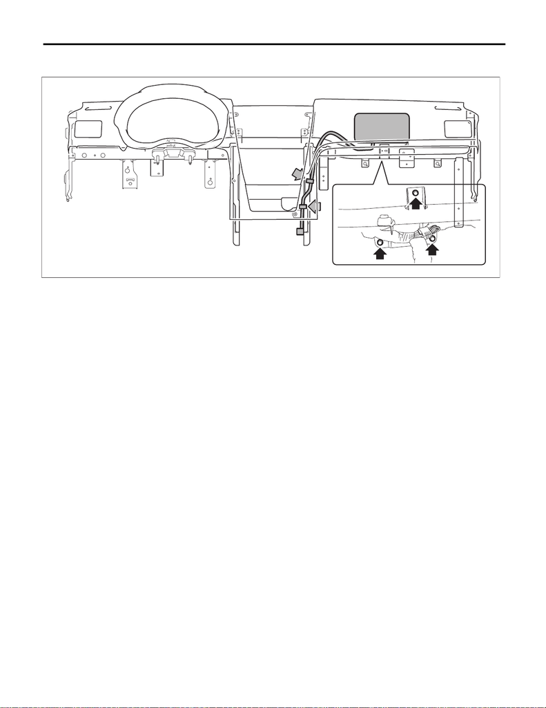

AB-39

Passenger’s Airbag Module

AIRBAG SYSTEM

21) Separate the panel COMPL - instrument and the beam COMPL - steering.

(1) Remove the clamps and bolts of the passenger’s airbag module harness.

(2) Disconnect the connectors of the left and right speakers and the sensor - sunload.

NOTE:

Detach the harness clamp together.

(3) Disconnect the front accessory socket connector.

(4) Remove the nut (a) and screws (b), (c), (d), (e), (f), (g) and (h).

EI-03449

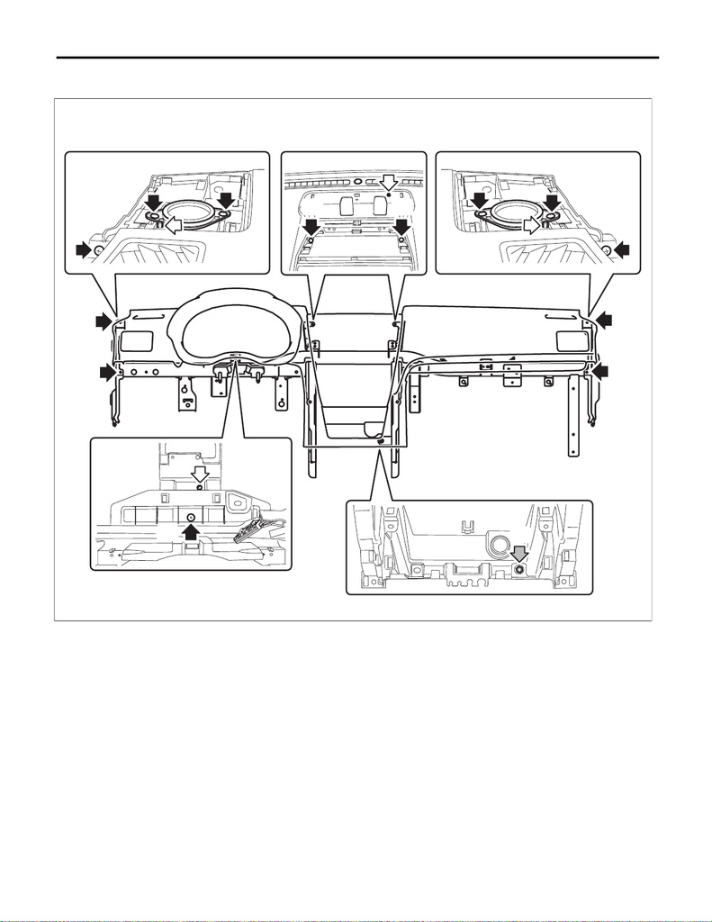

AB-40

Passenger’s Airbag Module

AIRBAG SYSTEM

(5) While being careful with the harness, separate the panel COMPL - instrument and the beam COMPL -

steering.

EI-03468

(b)

(d)

(b)

(d)

(e)

(c)

(a)

f

(g)

(h)

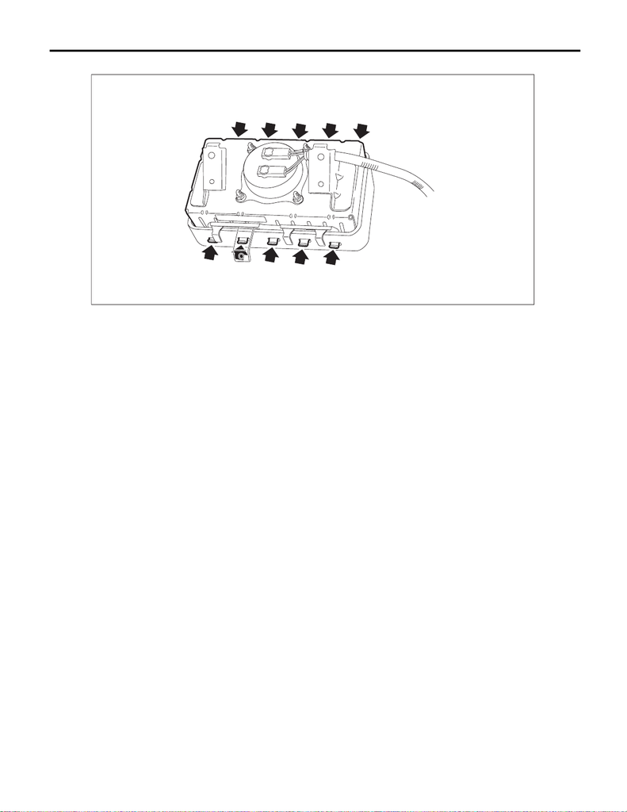

AB-41

Passenger’s Airbag Module

AIRBAG SYSTEM

22) Remove the claws, and remove the passenger’s airbag module.

23) For handling of the removed airbag module, refer to “CAUTION”. <Ref. to AB-9, CAUTION, General De-

scription.>

AB-03433

[figure not shown]

AB-42

Passenger’s Airbag Module

AIRBAG SYSTEM

B: INSTALLATION

CAUTION:

• Refer to “CAUTION” of “General Description” before handling the airbag module. <Ref. to AB-9,

CAUTION, General Description.>

• Do not allow harness and connectors to interfere or get tangled up with other parts.

• When reusing the tether clip on the upper part of the trim panel - front pillar UPR, check that there is

no damage to the tether clip. If the clip is damaged, its holding force is reduced and the trim panel -

front pillar UPR may come off. Be sure to replace it with a new clip.

1) Before installation, inspect the following items and replace any faulty part with a new one.

• Passenger’s airbag lid (instrument panel surface) is cracked or deformed.

• Airbag module is cracked or deformed.

• Harness and/or connector is cracked, deformed or open.

• Harness wire is exposed.

• Mounting bracket is cracked or deformed.

2) Install the instrument panel assembly. <Ref. to EI-77, INSTALLATION, Instrument Panel Assembly.>

3) Install the cover side sill - front on the RH and LH sides.

4) Install the cover side sill - front INN on the RH and LH sides.

5) Install the column assembly - steering. <Ref. to PS-28, INSTALLATION, Steering Column.>

6) Install the combination meter assembly.

7) Install the multi-function display assembly.

8) Install the audio assembly or navigation assembly.

9) Install the panel center assembly.

10) Install the globe box assembly.

11) Install the trim panel - front pillar UPR on the RH and LH sides. <Ref. to EI-87, INSTALLATION, Upper

Inner Trim.>

12) Install the grille speaker side on the RH and LH sides.

13) Install the knee airbag module.

Tightening torque:

7.5 N·m (0.8 kgf-m, 5.5 ft-lb)

14) Install the panel - switch. (Only model with keyless access)

15) Install the cover switch - starter. (Only model without keyless access)

16) Install the cover assembly - instrument panel LWR driver.

17) Install the panel center LWR on the RH and LH sides.

18) Install the cover - shift lever and the console box assembly.

19) Connect the battery ground terminal. <Ref. to NT-5, BATTERY, NOTE, Note.>

NOTE:

For models other than STI model, connect the ground terminal to battery sensor.